# What factors affect Airbnb pricing?

*Calvin Chan, Alex Huang, Kevin Huynh, Rachel Vuu*

*March 13th, 2019*

```python
import analysis
import model
```

## Purpose

For our final project, we selected the [Seattle Airbnb dataset](https://www.kaggle.com/airbnb/seattle), which contains a calendar file documenting the price point and availability of a listing on a day of the year and a descriptive file with a number of features including neighborhood, price, and ratings.

Airbnb is one of many technology companies that has completely transformed the sharing economy. Paving the way for other crowd-based marketplaces, Airbnb is one of several prominent startups collectively disrupted the business models of traditional industries (Satopaa & Mehrotra, 2018). Airbnb affords a platform for prospective guests to book accommodations with more flexibility and potentially lower price points, and for hosts to list their properties.

For the scope of this project, the audience we are targeting is potential Airbnb hosts who are considering investing in or renting out a property. For people who need extra income, Airbnb offers a self-regulating (via guest and host reviews), free-market solution for collecting short-term market-rate rents. However, inexperienced and longtime hosts may not be getting the most out of their listing and are missing out on potential revenue every rent day.

In an article by the New York Times, a host says that she grosses nearly $100,000 each year through Airbnb. Despite this income, she still does not feel financially secure due to the costs of upkeep as well as the “slower” months of January, February, and March (Dobbins, 2017). Depending on the location, property size, and other socio-economic factors, hosts may benefit more or less. Additionally, it has been found that Airbnb hosts use marketing logic to target specific demographics (Lutz & Newlands, 2017). A weak alignment between consumer segmentation and this host targeting can lead to potentially reduced matching efficiency. By performing data analyses on the features of the Seattle Airbnb dataset, we can draw insights on whether properties with a specific set of attributes bring more financial gain than others.

Through our resource, users will gain greater insight into what factors impact the price of a listing. Since there are so many different attributes for a listing, hosts will come with a better understanding of competitive prices. Hosts, interested with garnering high reviews, also will learn what factors influence ratings and reviews. This will allow hosts to stand out among the many listings, attracting more customers and making more money while maximizing the potential of their listing.

## Data Set

The original dataset containing descriptive information on listings was filled with features that were mostly of type string. After performing data cleaning and data type conversions, the data set below was produced.

```python
analysis.lis.head()
```

|  | id | name | summary | space | description | neighborhood_overview | notes | transit | host_about | host_listings_count | ... | monthly_price_float | host_is_super_host | host_response_rate_float | review_true_score | cancel_policy_code | property_code | neighbourhood_code | room_code | zipcode_code | geometry |
| --- | --- | --- | --- | --- | --- | --- | --- | --- | --- | --- | --- | --- | --- | --- | --- | --- | --- | --- | --- | --- | --- |
| 0 | 241032.0 | 4.0 | 0.0 | 180.0 | 180.0 | 0.0 | 0.0 | 0.0 | 73.0 | 3.0 | ... | 2585.27 | 0.0 | 0.96 | 3.8665 | 1 | 1 | 13 | 1 | 15 | POINT (-122.3710251999777 47.63628903835718) |
| 1 | 953595.0 | 6.0 | 39.0 | 145.0 | 152.0 | 28.0 | 172.0 | 28.0 | 14.0 | 6.0 | ... | 3000.00 | 1.0 | 0.98 | 1.4208 | 2 | 1 | 13 | 1 | 15 | POINT (-122.3656664643958 47.63912312136253) |
| 2 | 3308979.0 | 5.0 | 39.0 | 188.0 | 179.0 | 113.0 | 29.0 | 36.0 | 66.0 | 2.0 | ... | 29654.62 | 0.0 | 0.67 | 1.1155 | 2 | 10 | 13 | 1 | 15 | POINT (-122.3694831756176 47.62972413157735) |
| 3 | 0.0 | 0.0 | 0.0 | 0.0 | 0.0 | 0.0 | 0.0 | 0.0 | 0.0 | 0.0 | ... | 0.00 | 0.0 | 0.00 | 0.0000 | 0 | 0 | 0 | 0 | 0 | POINT (-122.3692791226302 47.63847320176642) |
| 4 | 278830.0 | 5.0 | 29.0 | 85.0 | 174.0 | 89.0 | 2.0 | 56.0 | 62.0 | 2.0 | ... | 13686.75 | 0.0 | 1.00 | 0.8188 | 2 | 10 | 13 | 1 | 15 | POINT (-122.3724706340222 47.63291840276724) |

5 rows × 46 columns

```python
analysis.cal.head()
```

|  | listing_id | date | price | is_available | datetime |
| --- | --- | --- | --- | --- | --- |
| 0 | 241032 | 2016-01-04 | $85.00 | 1 | 2016-01-04 |
| 1 | 241032 | 2016-01-05 | $85.00 | 1 | 2016-01-05 |
| 2 | 241032 | 2016-01-06 | NaN | 0 | 2016-01-06 |
| 3 | 241032 | 2016-01-07 | NaN | 0 | 2016-01-07 |
| 4 | 241032 | 2016-01-08 | NaN | 0 | 2016-01-08 |

## Exploratory Data Analysis

### Geography of Listings

The city of Seattle is especially diverse unique in its geography and surrounding landscape. Let's take a look at how Airbnb listings were scattered across the city:

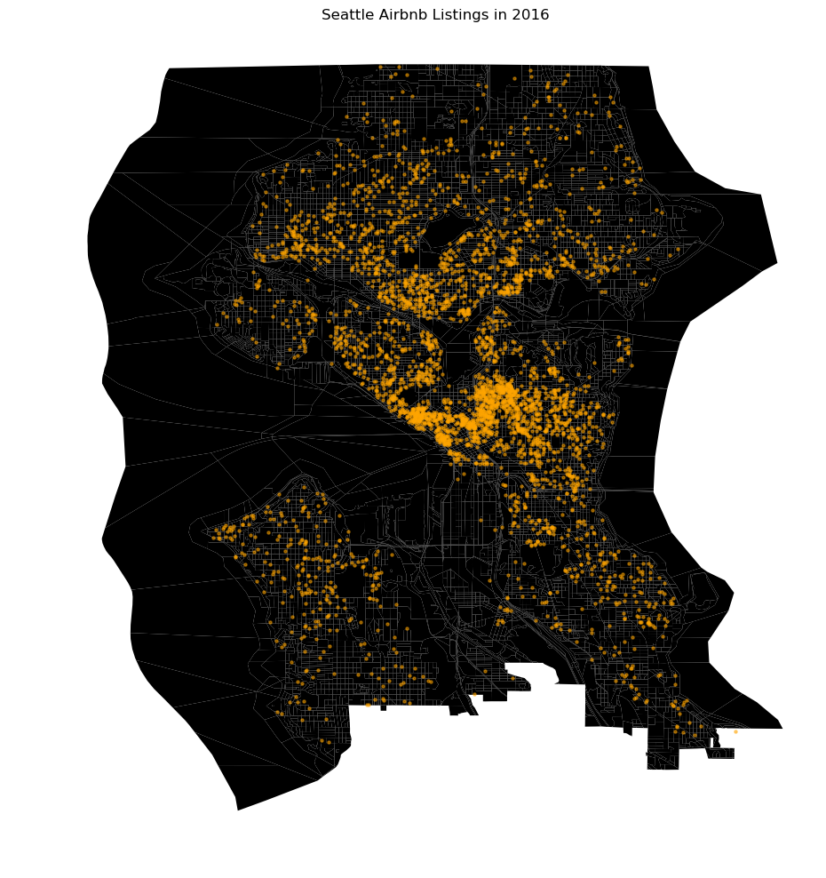

```python
analysis.fig_map_seattle_listings
```

**Observations:**

- Highest concentration of homestays are within Downtown and Capitol Hill
- Moderate concentration of homestays in the outer perimeters of central Seattle, with little to no homestays in the SoDo neighborhood below Downtown
- SoDo is part of the Industrial District, where warehouses and warehouse-style retail stores are more predominate and there are less residential zones
- Overall, there are more listings in the central and north parts of Seattle than south

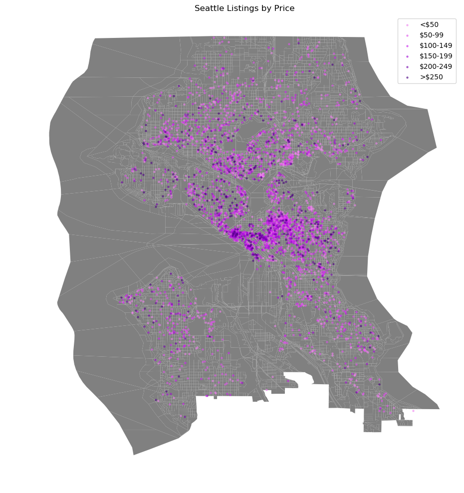

```python
analysis.fig_map_seattle_listings_price
```

**Observations:**

- Downtown and Capitol Hill, the most concentrated areas, tend to be more expensive
- This is expected since most tourist attractions are within that area
- Homestays in South Seattle tend to be marked at a lower price point than North and West Seattle
- These findings suggest there is a tradeoff between commute time to Downtown Seattle and price points for listings

### Listings by Time of Year

Time of year influences how many people come to Seattle and stay at an Airbnb. Our preliminary hypothesis is that more listings are available in the fall and winter months, since the weather is usually nicer in spring and summer. The graph below displays the number of available listings for Seattle in 2016:

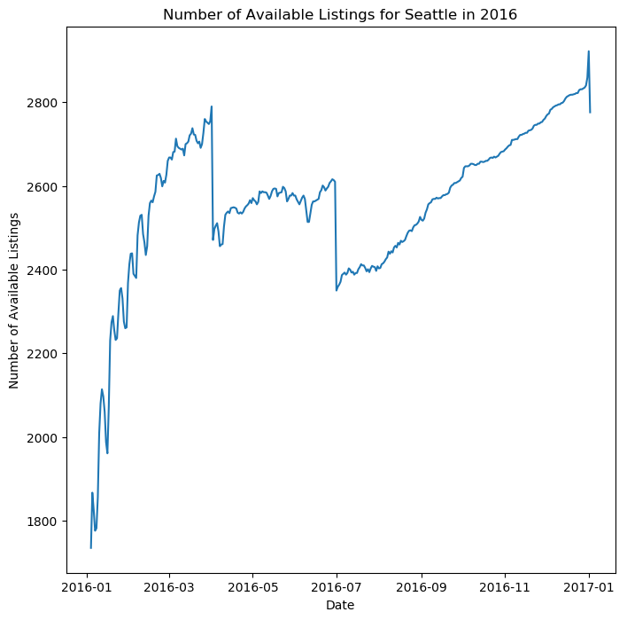

```python
analysis.fig_num_listings_by_date
```

**Observations:**

### Comparing Amenities with Price

Airbnb listings are required to list out the amenities they provide. Another hypothesis we had was that listings are considered to be better if they provide more listings, which would result in a higher price. Below is a visualization comparing the number of amenities to price:

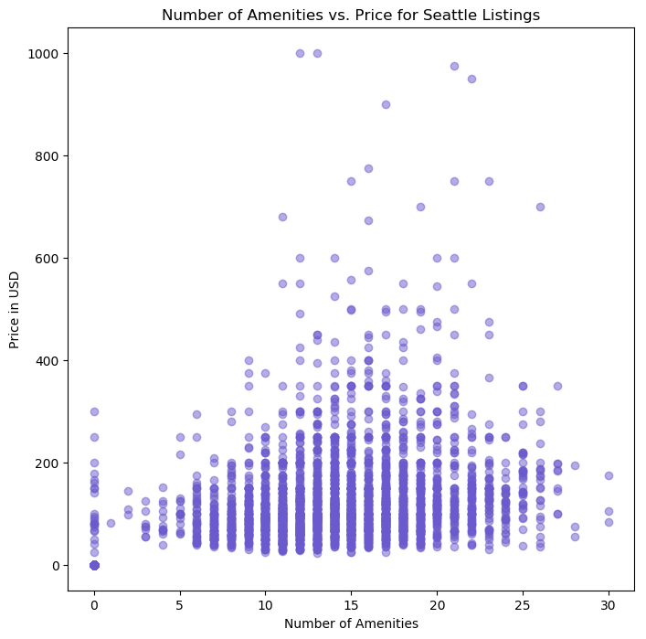

```python
analysis.fig_num_amenities_vs_price
```

**Observations:**

- There does not appear to be any correlation between number of amenities and price of listing.
- Units with few listed amenities can fall in the same price range as units with an upwards amount of 30 amenities.
- A data point at a price of $0 suggests there are inconsistencies in the data.

We also looked into specific amenities including bedrooms, beds, and bathrooms. They are some of the most important features of an Airbnb when determining where to stay.

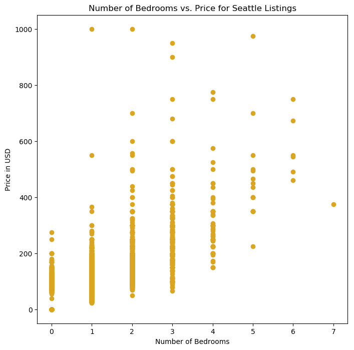

```python
analysis.fig_num_bedrooms_vs_price
```

**Observations:**

- Although there is some significant overlap, there is a general trend that the price of the homestay increases with the number of beds.
- There are some outliers in the data, such as the 1 bed homestay listed at \$1000. This could suggest several prospects: other characteristics such as location, amenities, or extravagance of the unit is strongly desirable, or there are inconsistencies in the data.
- Units with more bedrooms at lower price points could be due to the fact that the bedrooms are not actually available to the guest for use.

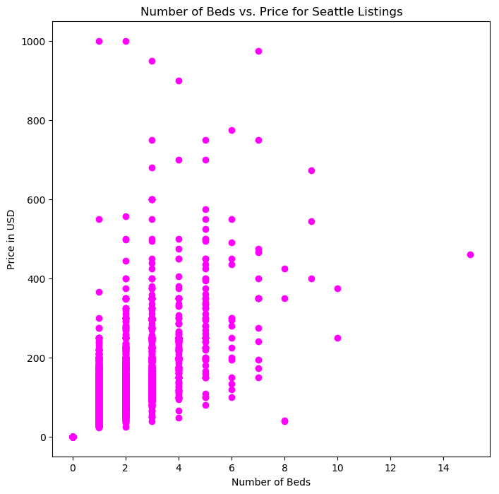

```python
analysis.fig_num_beds_vs_price
```

**Observations:**

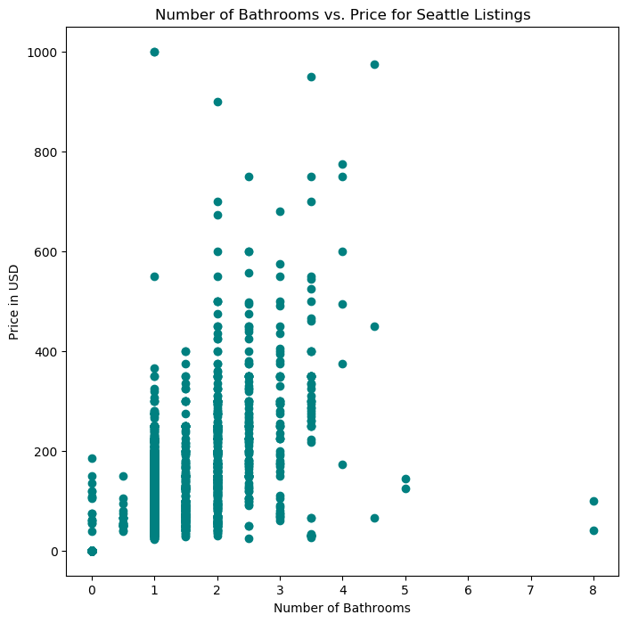

```python
analysis.fig_num_bathrooms_vs_price
```

**Observations:**

### Relationship Between Rating and Price

Another question of concern was whether rating and price were related. We initially considered whether listings with higher reviews would be listed at a higher price. However, listings at a more affordable rate could have high ratings as well. Below is are visualizations on describing the relationship between rating and price.

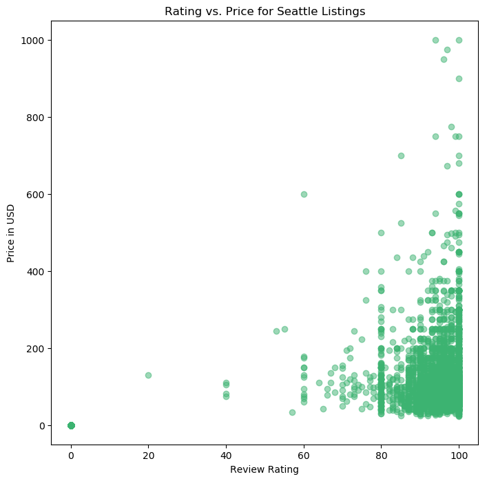

```python
analysis.fig_rating_vs_price
```

**Observations:**

- From the the review rating of 60+, there is a moderate positive correlation between the review ratings and the price point of the Airbnb.
- Most Airbnbs have 80+ review ratings, and it did not seem like there is a signficant correlation between review ratings and price.
- Among the most expensive listings, they all have above 90 review ratings - signifying that they are quality listings that are worth the high price.

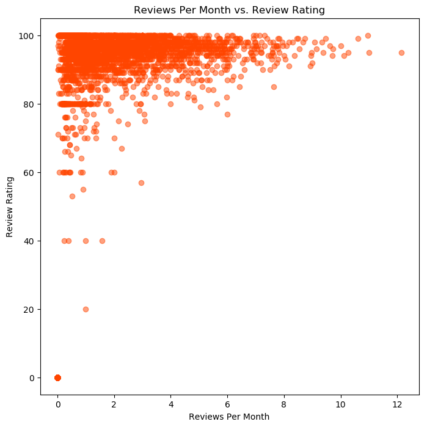

```python
analysis.fig_reviews_per_month_vs_price
```

**Observations:**

- In terms of the correlation between reviews per month and review ratings, there was a positive correlation between the two variables.
- Airbnbs that have review ratings of above 85 had much more reviews per month than the properties that had less ratings - suggesting that there is a significantly more amount of people each people that are giving them business and providing reviews.
- This is important because it suggests that having high review ratings means there will be more reviews per month, which also means more business per month.
- Those properties with much lower review ratings had much less reviews per month, suggesting they have less business per month.

# Modeling

### Correlation Features Heat Map

We began our feature engineering by comparing all of our converted float values in a correlation map to see and remove any confounding variables. We came to the result below with the help of forward selection. We used forward selection in this case because we wanted to see what features being added onto a listing would increase the price the most rather than what we should remove in terms of features. We ensured that each feature of the model had a p-value of less than 0.05 or we would remove them. The end result is the correlation map down below and the features we used for all of the regressions. We can see there are some high correlations between some of the variables such as latitude and rating, but these seems to be nonsensical.

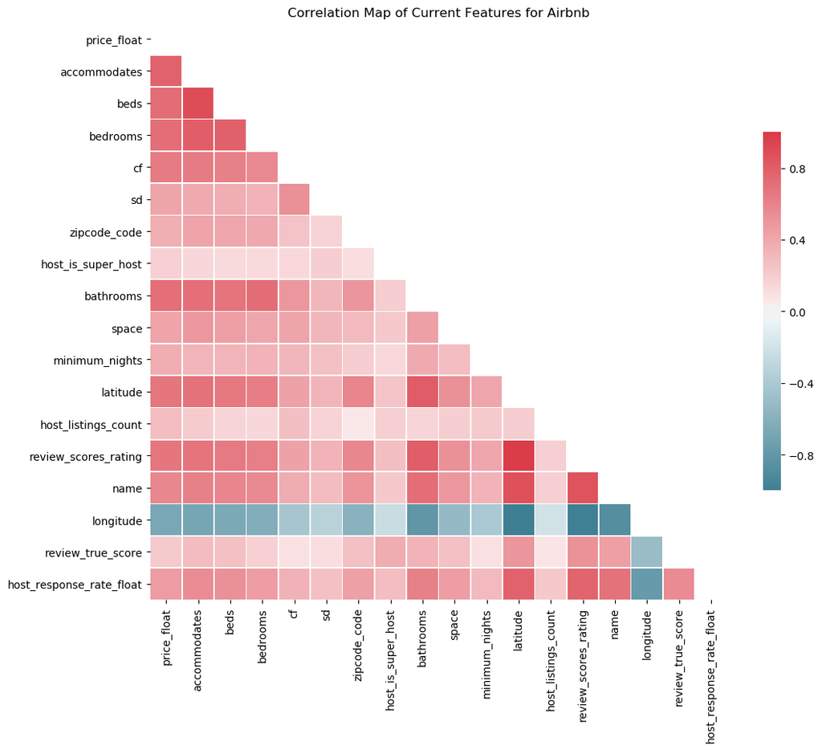

```python
model.f
```

## Baseline Linear Regression

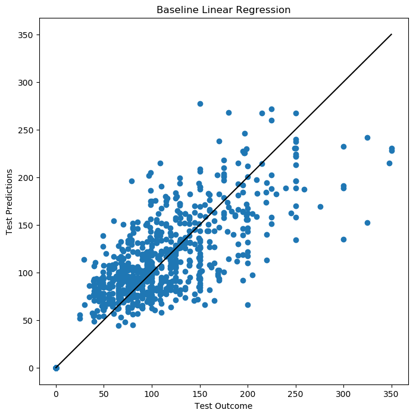

```python
model.fig_blr
```

```python
model.base_lin_score
```

```
24.464345385731573
```

## Ridge Linear Regression

This model solves a regression model where the loss function is the linear least squares function and regularization is given by the l2-norm. Also known as Ridge Regression or Tikhonov regularization. This estimator has built-in support for multi-variate regression. The overall model began to low ball on the predictions less, but the overall score did not improve significantly or anything at all.

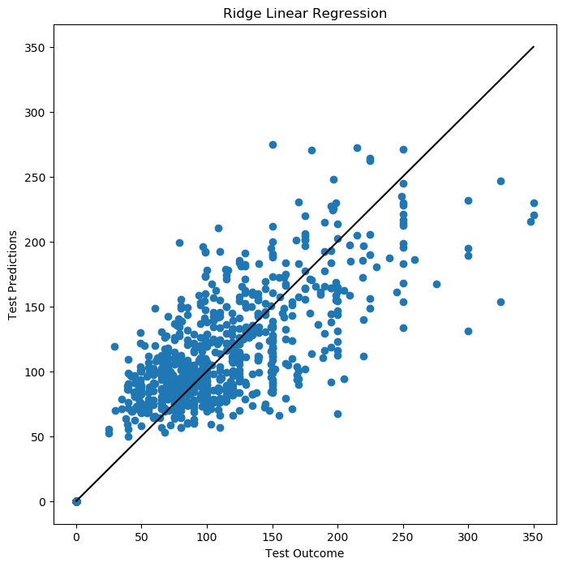

```python
model.fig_rlr
```

```python
model.ridge_score
```

```
-24.620687686875975
```

## Negative Binomial Regression

Our dataset was observed to be highly skewed to the right, so we believed that this model would fit and perform the best with our current dataset where the Negative Binomial Regression usually works better. The Negative Binomial Regression did perform the best out of the linear regressions by a slight margin, but loses significantly to the XGBooster Regression. The model performed badly at the higher end where it overshoots and undershoots significantly.

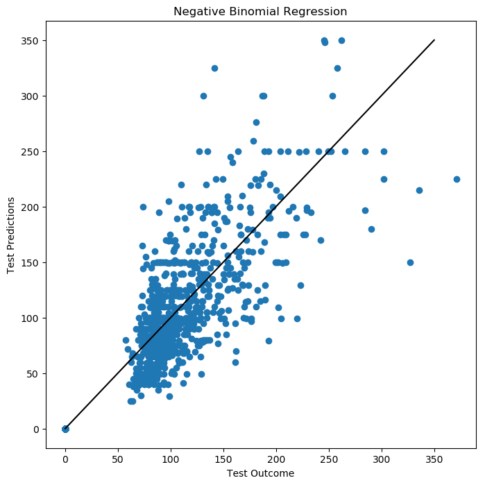

```python
model.fig_nbr
```

```python
model.nbr_score
```

```
24.366550225380006
```

## K-Nearest Neighbors Regression

The target is predicted by local interpolation of the targets associated of the nearest neighbors in the training set. K-Nearest Neighbors worked well in determine the data at the lower end where most of the data was grouped up our dataset, but once we moved into the higher values where outliers became more prominent the model begins to fall off and low balls once again.

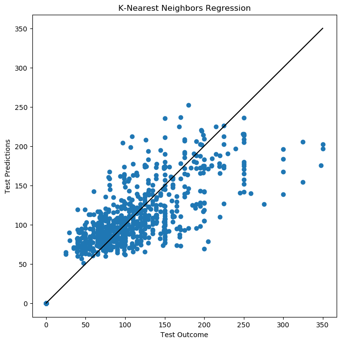

```python
model.fig_knn
```

```python
model.knn_score
```

```
-23.219322167824934
```

## XG Booster Regression

Also known as **Extreme Gradient Boosting**.

The implementation of the model supports the features of the scikit-learn and R implementations, with new additions like regularization. Three main forms of gradient boosting are supported:

```
- Gradient Boosting algorithm also called gradient boosting machine including the learning rate.
- Stochastic Gradient Boosting with sub-sampling at the row, column and column per split levels.
- Regularized Gradient Boosting with both L1 and L2 regularization.
```

This became our best overall model with means absolute error score of 20.76. The XGBoost Regression was able to compensate for the outliers and bring the higher end points closer to the actual values overall.

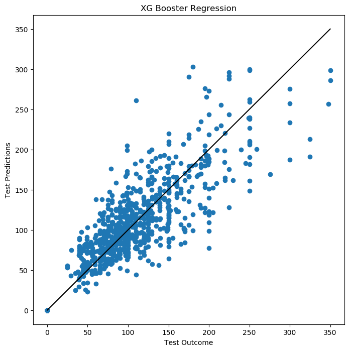

```python
model.fig_xbg
```

```python
model.xgb_score
```

```
-20.756329545794152
```